# Project Foundations for Data Science: FoodHub Data Analysis

**Marks: 60**

### Context

The number of restaurants in New York is increasing day by day. Lots of students and busy professionals rely on those restaurants due to their hectic lifestyles. Online food delivery service is a great option for them. It provides them with good food from their favorite restaurants. A food aggregator company FoodHub offers access to multiple restaurants through a single smartphone app.

The app allows the restaurants to receive a direct online order from a customer. The app assigns a delivery person from the company to pick up the order after it is confirmed by the restaurant. The delivery person then uses the map to reach the restaurant and waits for the food package. Once the food package is handed over to the delivery person, he/she confirms the pick-up in the app and travels to the customer's location to deliver the food. The delivery person confirms the drop-off in the app after delivering the food package to the customer. The customer can rate the order in the app. The food aggregator earns money by collecting a fixed margin of the delivery order from the restaurants.

### Objective

The food aggregator company has stored the data of the different orders made by the registered customers in their online portal. They want to analyze the data to get a fair idea about the demand of different restaurants which will help them in enhancing their customer experience. Suppose you are hired as a Data Scientist in this company and the Data Science team has shared some of the key questions that need to be answered. Perform the data analysis to find answers to these questions that will help the company to improve the business.

### Data Description

The data contains the different data related to a food order. The detailed data dictionary is given below.

### Data Dictionary

- order_id: Unique ID of the order
- customer_id: ID of the customer who ordered the food
- restaurant_name: Name of the restaurant
- cuisine_type: Cuisine ordered by the customer
- cost: Cost of the order
- day_of_the_week: Indicates whether the order is placed on a weekday or weekend (The weekday is from Monday to Friday and the weekend is Saturday and Sunday)
- rating: Rating given by the customer out of 5
- food_preparation_time: Time (in minutes) taken by the restaurant to prepare the food. This is calculated by taking the difference between the timestamps of the restaurant's order confirmation and the delivery person's pick-up confirmation.
- delivery_time: Time (in minutes) taken by the delivery person to deliver the food package. This is calculated by taking the difference between the timestamps of the delivery person's pick-up confirmation and drop-off information

### Let us start by importing the required libraries

```python
# import libraries for data manipulation
import numpy as np
import pandas as pd

# import libraries for data visualization
import matplotlib.pyplot as plt
import seaborn as sns
%matplotlib inline
from matplotlib import rcParams # import rcParams from matplotlib

plt.style.use("ggplot")
rcParams['figure.figsize'] = (12,  6)
```

### Understanding the structure of the data

```python
# Mount Google drive for reading dataset

from google.colab import drive
drive.mount('/content/drive')
```

```python
# read the data
df = pd.read_csv('/content/drive/MyDrive/1.PROGETTI/2024.09.Corso Mit /Capston 01 Week 01-02 /foodhub_order.csv')
# returns the first 5 rows
df.head()
```

|  | order_id | customer_id | restaurant_name | cuisine_type | cost_of_the_order | day_of_the_week | rating | food_preparation_time | delivery_time |
| --- | --- | --- | --- | --- | --- | --- | --- | --- | --- |
| 0 | 1477147 | 337525 | Hangawi | Korean | 30.75 | Weekend | Not given | 25 | 20 |
| 1 | 1477685 | 358141 | Blue Ribbon Sushi Izakaya | Japanese | 12.08 | Weekend | Not given | 25 | 23 |
| 2 | 1477070 | 66393 | Cafe Habana | Mexican | 12.23 | Weekday | 5 | 23 | 28 |
| 3 | 1477334 | 106968 | Blue Ribbon Fried Chicken | American | 29.20 | Weekend | 3 | 25 | 15 |
| 4 | 1478249 | 76942 | Dirty Bird to Go | American | 11.59 | Weekday | 4 | 25 | 24 |

#### **Observations**:

The DataFrame has 9 columns as mentioned in the Data Dictionary. Data in each row corresponds to the order placed by a customer.

### **Question 1:** How many rows and columns are present in the data? [0.5 mark]

```python
# Write your code here
df.shape # return a tuple for row and Coloumn
print("There are", df.shape[0], 'rows and', df.shape[1], "columns.")
```

```
There are 1898 rows and 9 columns.
```

**#### Observations**: Dataset it's compose by 1898 row and 9 coloumn.

### **Question 2:** What are the datatypes of the different columns in the dataset? (The info() function can be used) [0.5 mark]

```python
# Use info() to print a concise summary of the DataFrame
df.info()
```

```
<class 'pandas.core.frame.DataFrame'>
RangeIndex: 1898 entries, 0 to 1897
Data columns (total 9 columns):
 #   Column                 Non-Null Count  Dtype
---  ------                 --------------  -----
 0   order_id               1898 non-null   int64
 1   customer_id            1898 non-null   int64
 2   restaurant_name        1898 non-null   object
 3   cuisine_type           1898 non-null   object
 4   cost_of_the_order      1898 non-null   float64
 5   day_of_the_week        1898 non-null   object
 6   rating                 1898 non-null   object
 7   food_preparation_time  1898 non-null   int64
 8   delivery_time          1898 non-null   int64
dtypes: float64(1), int64(4), object(4)
memory usage: 133.6+ KB
```

#### **Observations**:

- All columns have 1898 non-null values, indicating no missing data
- datatype its appropriate:
- Integer: order_id, customer_id ,food_preparation_time, delivery_time
- Floating-point: cost_of_the_order *Object: restaurant_name, cuisine_type, day_of_the_week, rating.

### **Question 3:** Are there any missing values in the data? If yes, treat them using an appropriate method. [1 mark]

```python
# Write your code here
df.isnull().sum() # Check for missing values
```

|  | 0 |
| --- | --- |
| order_id | 0 |
| customer_id | 0 |
| restaurant_name | 0 |
| cuisine_type | 0 |
| cost_of_the_order | 0 |
| day_of_the_week | 0 |
| rating | 0 |
| food_preparation_time | 0 |
| delivery_time | 0 |

**dtype:** int64

#### **Observations**:

No missing value on Dataset

### **Question 4:** Check the statistical summary of the data. What is the minimum, average, and maximum time it takes for food to be prepared once an order is placed? [2 marks]

```python
# Write your code here
df.describe(include='all').T # Statistical summary of the data
```

|  | count | unique | top | freq | mean | std | min | 25% | 50% | 75% | max |
| --- | --- | --- | --- | --- | --- | --- | --- | --- | --- | --- | --- |
| order_id | 1898.0 | NaN | NaN | NaN | 1477495.5 | 548.049724 | 1476547.0 | 1477021.25 | 1477495.5 | 1477969.75 | 1478444.0 |
| customer_id | 1898.0 | NaN | NaN | NaN | 171168.478398 | 113698.139743 | 1311.0 | 77787.75 | 128600.0 | 270525.0 | 405334.0 |
| restaurant_name | 1898 | 178 | Shake Shack | 219 | NaN | NaN | NaN | NaN | NaN | NaN | NaN |
| cuisine_type | 1898 | 14 | American | 584 | NaN | NaN | NaN | NaN | NaN | NaN | NaN |
| cost_of_the_order | 1898.0 | NaN | NaN | NaN | 16.498851 | 7.483812 | 4.47 | 12.08 | 14.14 | 22.2975 | 35.41 |
| day_of_the_week | 1898 | 2 | Weekend | 1351 | NaN | NaN | NaN | NaN | NaN | NaN | NaN |
| rating | 1898 | 4 | Not given | 736 | NaN | NaN | NaN | NaN | NaN | NaN | NaN |
| food_preparation_time | 1898.0 | NaN | NaN | NaN | 27.37197 | 4.632481 | 20.0 | 23.0 | 27.0 | 31.0 | 35.0 |
| delivery_time | 1898.0 | NaN | NaN | NaN | 24.161749 | 4.972637 | 15.0 | 20.0 | 25.0 | 28.0 | 33.0 |

**#### Observations:**

- **Order ID**: There are 1,898 unique orders, and their IDs range from 1,476,547 to 1,478,444.
- **Customer ID**: Customers also range widely, with an average ID of 171,168, which likely reflects many customers.
- **Restaurant Name**: There are 178 unique restaurants, with "Shake Shack" being the most frequent (219 orders).
- **Cuisine Type**: There are 14 distinct types of cuisine, with "American" being the most popular (584 orders).
- **Cost of the Order**: The average cost of an order is 16.50$. Min 4.47 and Max 35.41$
- **Day of the Week**: Most orders were placed on the Weekend (1,351 orders compared to 547 on weekdays).
- **Rating**: There are 4 unique ratings, and 736 orders do not have ratings ("Not given").
- **Food Preparation Time**: The average preparation time is 27.37 minutes, ranging from 20 to 35 minutes.
- **Delivery Time:** The average delivery time is 24.16 minutes, with a minimum of 15 minutes and a maximum of 33 minutes.

### **Question 5:** How many orders are not rated? [1 mark]

```python
# Write the code here
print(df['rating'].value_counts()) # Count the occurrences of each unique value in the rating column of your DataFrame df
```

```
rating
Not given    736
5            588
4            386
3            188
Name: count, dtype: int64
```

```python
# Write the code here
round(df['rating'].value_counts(normalize=True),2)*100 #calculates the proportions of each unique value in the rating column of your DataFrame df and rounds them to two decimal places, then multiplies by 100 to get percentages
```

| rating | proportion |
| --- | --- |
| Not given | 39.0 |
| 5 | 31.0 |
| 4 | 20.0 |
| 3 | 10.0 |

**dtype:** float64

#### **Observations:**

- "Not given" is the most frequent: Almost 39% of ratings are "Not given," indicating a significant portion of customers either didn't provide a rating or the rating was not recorded.
- 31% of customers gave the highest rating of 5, suggesting a reasonable level of customer satisfaction.
- Suggest an investigation of Order Not rated

### Exploratory Data Analysis (EDA)

### **Question 6:** Explore all the variables and provide observations on their distributions. (Generally, histograms, boxplots, countplots, etc. are used for univariate exploration.) [9 marks]

```python
# Write the code here

df.columns # List of column names
```

```
Index(['order_id', 'customer_id', 'restaurant_name', 'cuisine_type',
       'cost_of_the_order', 'day_of_the_week', 'rating',
       'food_preparation_time', 'delivery_time'],
      dtype='object')
```

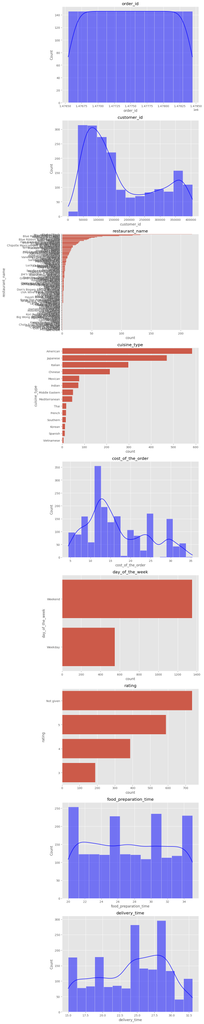

```python
plt.figure(figsize=(10, 50))
for i in range(len(df.columns)):
    plt.subplot(9, 1, i + 1)

    # Check if the column contains numeric data before plotting
    if pd.api.types.is_numeric_dtype(df[df.columns[i]]):
        sns.histplot(df[df.columns[i]], kde=True, color='b')
        plt.title(df.columns[i])
    else:
        # Handle non-numeric columns with countplots
        sns.countplot(y=df[df.columns[i]], order=df[df.columns[i]].value_counts().index)
        plt.title(df.columns[i])

plt.tight_layout()
plt.show()
```

**Observation**

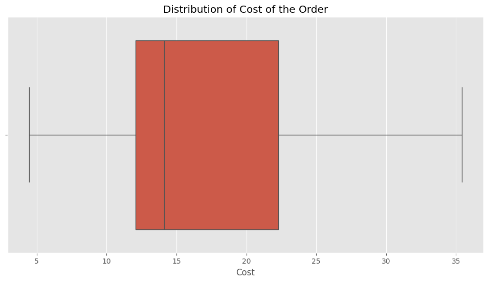

```python
sns.boxplot(x=df['cost_of_the_order']) # box plot
plt.title('Distribution of Cost of the Order')
plt.xlabel('Cost')
plt.show()
```

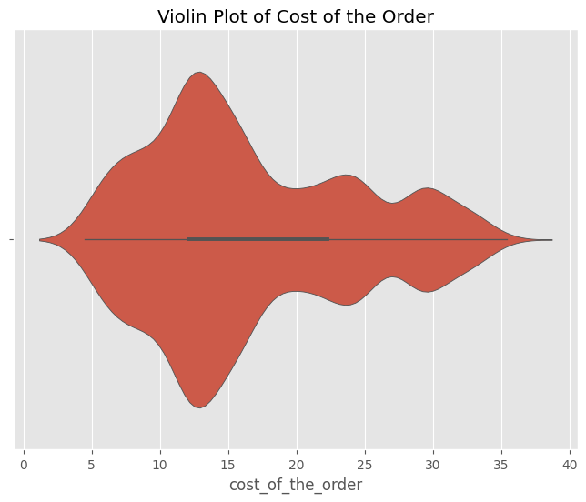

```python
plt.figure(figsize=(8, 6))
sns.violinplot(x=df['cost_of_the_order'])
plt.title('Violin Plot of Cost of the Order')
plt.show()
```

The box plot shows that the distribution of order costs is some skewed to the right, with a longer tail on the right side. This indicates that there are some orders with significantly higher costs compared to the majority.

### **Question 7**: Which are the top 5 restaurants in terms of the number of orders received? [1 mark]

```python
# Write the code here

top_restaurants = df['restaurant_name'].value_counts(ascending=False).head(5) #Counts the occurrences of each unique value and sort he results in descending order, so the most frequent restaurant appears first.
top_restaurants
```

| restaurant_name | count |
| --- | --- |
| Shake Shack | 219 |
| The Meatball Shop | 132 |
| Blue Ribbon Sushi | 119 |
| Blue Ribbon Fried Chicken | 96 |
| Parm | 68 |

**dtype:** int64

#### Observations:

### **Question 8**: Which is the most popular cuisine on weekends? [1 mark]

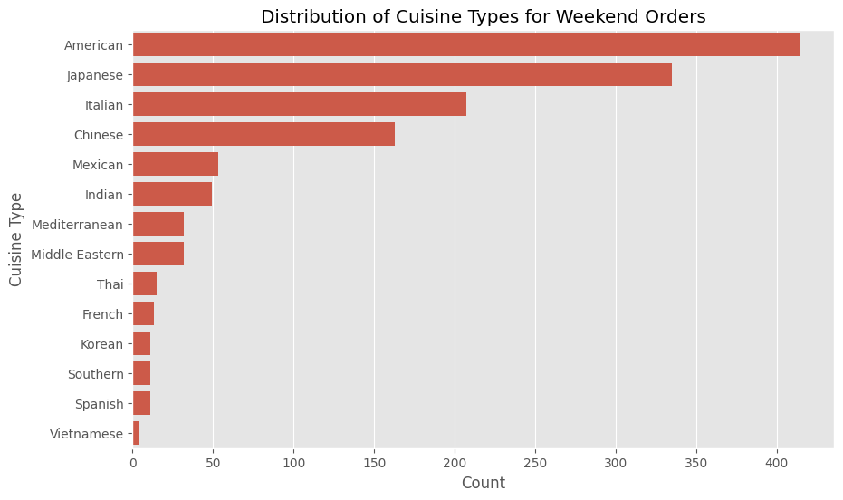

```python
weekend_data = df[df['day_of_the_week'] == 'Weekend']

plt.figure(figsize=(10, 6))
sns.countplot(y=weekend_data['cuisine_type'], order=weekend_data['cuisine_type'].value_counts().index)
plt.title('Distribution of Cuisine Types for Weekend Orders')
plt.xlabel('Count')
plt.ylabel('Cuisine Type')
plt.show()
```

```python
# Write the code here
popular_cuisine = df[df['day_of_the_week'] == 'Weekend']['cuisine_type'].value_counts().idxmax()
popular_cuisine
```

```
'American'
```

#### Observations:

### **Question 9**: What percentage of the orders cost more than 20 dollars? [2 marks]

```python
# Write the code here
total_orders = len(df['order_id'].unique())  # Get the total number of unique orders
orders_over_20 = df[df['cost_of_the_order'] > 20]
percentage_high_cost = (len(orders_over_20) / total_orders) * 100 # Use len() to get the count of orders over 20
round(percentage_high_cost,2)
```

```
29.24
```

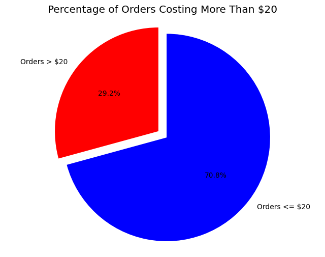

```python
# Visualizing the percentage of orders that cost more than $20

plt.figure(figsize=(8, 6))
labels = ['Orders > $20', 'Orders <= $20']
# Get the number of orders over $20
num_orders_over_20 = len(orders_over_20)
# Use num_orders_over_20 instead of the DataFrame
sizes = [num_orders_over_20, total_orders - num_orders_over_20]
colors = ['r', 'b']

plt.pie(sizes, labels=labels, colors=colors, autopct='%1.1f%%', startangle=90, explode=(0.1, 0))
plt.title('Percentage of Orders Costing More Than $20')
plt.axis('equal')  # Equal aspect ratio ensures that pie is drawn as a circle
plt.show()
```

#### **Observations**:

29.24% of the orders cost more than 20 dollars

### **Question 10**: What is the mean order delivery time? [1 mark]

```python
# Write the code here
mean_delivery_time = df['delivery_time'].mean()
round(mean_delivery_time,2)
```

```
24.16
```

[output not shown]

[output cut: 21 more lines]

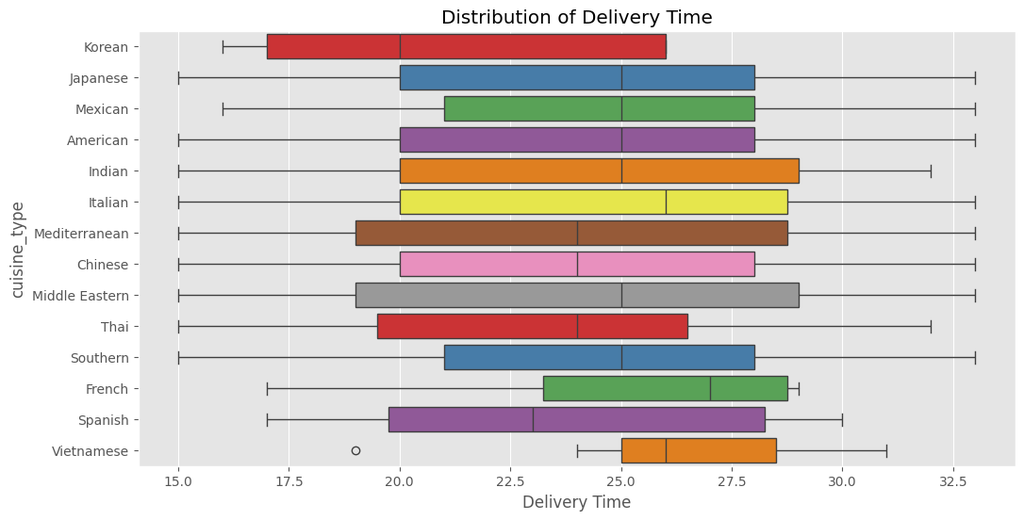

```python
sns.boxplot(x=df['delivery_time'], y=df['cuisine_type'], palette='Set1')
plt.title('Distribution of Delivery Time')
plt.xlabel('Delivery Time')
plt.show()
```

#### **Observations:**

The mean order delivery time is 24.16 minutes.

### **Question 11:** The company has decided to give 20% discount vouchers to the top 3 most frequent customers. Find the IDs of these customers and the number of orders they placed. [1 mark]

```python
# Write the code here
top_customers = df['customer_id'].value_counts()
top_customers.head(3)
```

| customer_id | count |
| --- | --- |
| 52832 | 13 |
| 47440 | 10 |
| 83287 | 9 |

**dtype:** int64

#### Observations:

These are the best 3 customers in terms of the number of orders placed.

### **Question 12**: Perform a multivariate analysis to explore relationships between the important variables in the dataset. (It is a good idea to explore relations between numerical variables as well as relations between numerical and categorical variables) [10 marks]

```python
# Write the code here
df.info()
```

```
<class 'pandas.core.frame.DataFrame'>
RangeIndex: 1898 entries, 0 to 1897
Data columns (total 9 columns):
 #   Column                 Non-Null Count  Dtype
---  ------                 --------------  -----
 0   order_id               1898 non-null   int64
 1   customer_id            1898 non-null   int64
 2   restaurant_name        1898 non-null   object
 3   cuisine_type           1898 non-null   object
 4   cost_of_the_order      1898 non-null   float64
 5   day_of_the_week        1898 non-null   object
 6   rating                 1898 non-null   object
 7   food_preparation_time  1898 non-null   int64
 8   delivery_time          1898 non-null   int64
dtypes: float64(1), int64(4), object(4)
memory usage: 133.6+ KB
```

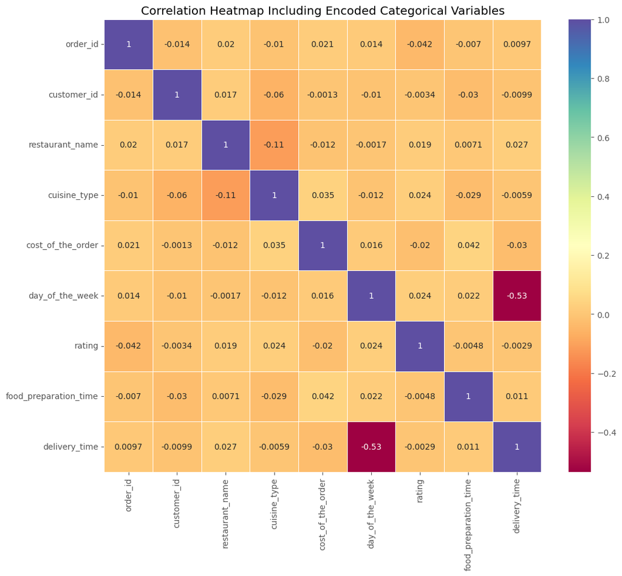

```python
from sklearn.preprocessing import LabelEncoder

# Create a copy of the data to work on
data_encoded = df.copy()

# List of categorical columns to encode
categorical_cols = ['restaurant_name', 'cuisine_type', 'day_of_the_week', 'rating']

# Apply Label Encoding to the categorical columns
label_encoder = LabelEncoder()
for col in categorical_cols:
    data_encoded[col] = label_encoder.fit_transform(data_encoded[col])

# Calculate the correlation matrix
correlation_matrix_encoded = data_encoded.corr()

# Plot the correlation heatmap with encoded categorical variables
plt.figure(figsize=(12, 10))
sns.heatmap(correlation_matrix_encoded, annot=True, cmap='Spectral', linewidths=0.5)
plt.title('Correlation Heatmap Including Encoded Categorical Variables')
plt.show()
```

**Observatiion**:

```python
correlation_matrix_encoded
```

|  | order_id | customer_id | restaurant_name | cuisine_type | cost_of_the_order | day_of_the_week | rating | food_preparation_time | delivery_time |
| --- | --- | --- | --- | --- | --- | --- | --- | --- | --- |
| order_id | 1.000000 | -0.013960 | 0.020276 | -0.010100 | 0.021171 | 0.013971 | -0.042083 | -0.007026 | 0.009690 |
| customer_id | -0.013960 | 1.000000 | 0.017099 | -0.060482 | -0.001322 | -0.010313 | -0.003354 | -0.030330 | -0.009885 |
| restaurant_name | 0.020276 | 0.017099 | 1.000000 | -0.110332 | -0.012247 | -0.001656 | 0.018933 | 0.007109 | 0.026797 |
| cuisine_type | -0.010100 | -0.060482 | -0.110332 | 1.000000 | 0.035184 | -0.012140 | 0.023558 | -0.028737 | -0.005913 |
| cost_of_the_order | 0.021171 | -0.001322 | -0.012247 | 0.035184 | 1.000000 | 0.015960 | -0.020015 | 0.041527 | -0.029949 |
| day_of_the_week | 0.013971 | -0.010313 | -0.001656 | -0.012140 | 0.015960 | 1.000000 | 0.024009 | 0.021970 | -0.534801 |
| rating | -0.042083 | -0.003354 | 0.018933 | 0.023558 | -0.020015 | 0.024009 | 1.000000 | -0.004847 | -0.002858 |
| food_preparation_time | -0.007026 | -0.030330 | 0.007109 | -0.028737 | 0.041527 | 0.021970 | -0.004847 | 1.000000 | 0.011094 |
| delivery_time | 0.009690 | -0.009885 | 0.026797 | -0.005913 | -0.029949 | -0.534801 | -0.002858 | 0.011094 | 1.000000 |

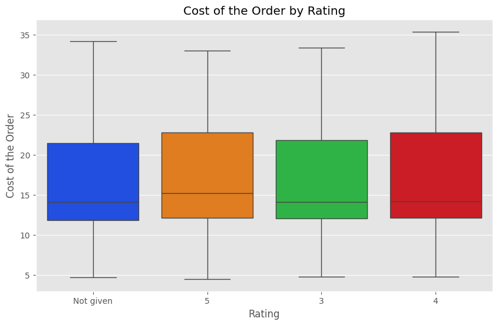

```python
# Exploring the relationship between cost of the order and rating using a boxplot
plt.figure(figsize=(10, 6))
sns.boxplot(x='rating', y='cost_of_the_order', data=df,palette='bright' )
plt.title('Cost of the Order by Rating')
plt.xlabel('Rating')
plt.ylabel('Cost of the Order')
plt.show()
```

**Observation:** Across all rating categories, the median cost hovers around 15, and the range is consistent, spanning from around 5 to 35.

[output not shown]

[output cut: 21 more lines]

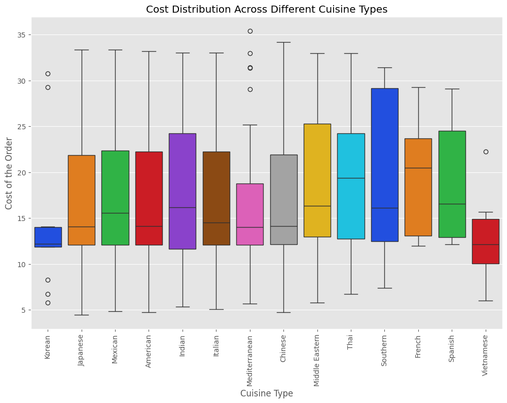

```python
# Boxplot to investigate the cost distribution across different cuisine types
plt.figure(figsize=(12, 8))
sns.set_palette('Set3')
sns.boxplot(x='cuisine_type', y='cost_of_the_order', data=df, palette='bright')
plt.xticks(rotation=90)
plt.title('Cost Distribution Across Different Cuisine Types')
plt.xlabel('Cuisine Type')
plt.ylabel('Cost of the Order')
plt.show()
```

**Observation**:

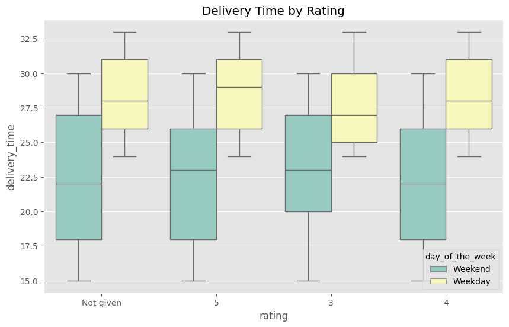

```python
plt.figure(figsize=(10, 6))
sns.boxplot(x='rating', y='delivery_time', hue='day_of_the_week', data=df)
plt.title('Delivery Time by Rating')
plt.show()
```

**Observation:**

- The day of the week plays a noticeable role in delivery times, with weekend deliveries generally being faster.
- Orders that were not rated have similar delivery times compared to those that were rated 3, 4, or 5 stars, suggesting that delivery time does not strongly influence whether an order is rated or how highly it is rated.

### **Question 13:** The company wants to provide a promotional offer in the advertisement of the restaurants. The condition to get the offer is that the restaurants must have a rating count of more than 50 and the average rating should be greater than 4. Find the restaurants fulfilling the criteria to get the promotional offer. [3 marks]

```python
# Write the code here
# Filter out restaurants with more than 50 ratings and an average rating greater than 4
restaurant_ratings = df[df['rating'] != 'Not given']  # Exclude 'Not given' ratings

# Convert ratings to numeric for proper calculation
restaurant_ratings['rating'] = pd.to_numeric(restaurant_ratings['rating'])

# Group by restaurant and calculate the number of ratings and average rating
restaurant_summary = restaurant_ratings.groupby('restaurant_name').agg(
    rating_count=('rating', 'count'),
    average_rating=('rating', 'mean')
).reset_index()

# Apply the conditions for the promotional offer
promotional_offer_restaurants = restaurant_summary[
    (restaurant_summary['rating_count'] > 50) & (restaurant_summary['average_rating'] > 4)
]

# Display the resulting restaurants
promotional_offer_restaurants
```

|  | restaurant_name | rating_count | average_rating |
| --- | --- | --- | --- |
| 16 | Blue Ribbon Fried Chicken | 64 | 4.328125 |
| 17 | Blue Ribbon Sushi | 73 | 4.219178 |
| 117 | Shake Shack | 133 | 4.278195 |
| 132 | The Meatball Shop | 84 | 4.511905 |

#### Observations:

### **Question 14:** The company charges the restaurant 25% on the orders having cost greater than 20 dollars and 15% on the orders having cost greater than 5 dollars. Find the net revenue generated by the company across all orders. [3 marks]

```python
# Write the code here
# Group the data by restaurant name and count the total number of orders per restaurant
total_orders_per_restaurant = df['restaurant_name'].value_counts()

# Display the total number of orders per restaurant
total_orders_per_restaurant
```

| restaurant_name | count |
| --- | --- |
| Shake Shack | 219 |
| The Meatball Shop | 132 |
| Blue Ribbon Sushi | 119 |
| Blue Ribbon Fried Chicken | 96 |
| Parm | 68 |
| ... | ... |
| Sushi Choshi | 1 |
| Dos Caminos Soho | 1 |
| La Follia | 1 |
| Philippe Chow | 1 |
| 'wichcraft | 1 |

178 rows × 1 columns

**dtype:** int64

```python
# Function to calculate the commission based on the order cost
def calculate_commission(cost):
    if cost > 20:
        return cost * 0.25
    elif cost > 5:
        return cost * 0.15
    else:
        return 0  # No commission for orders <= 5 dollars

# Apply the commission calculation function to each order
df['commission'] = df['cost_of_the_order'].apply(calculate_commission)

# Calculate the total net revenue by summing all the commissions
net_revenue = df['commission'].sum()

# Display the net revenue
net_revenue
```

```
6166.303
```

#### **Observations:**

The total Commission for company it's $ 6166.30

### **Question 15:** The company wants to analyze the total time required to deliver the food. What percentage of orders take more than 60 minutes to get delivered from the time the order is placed? (The food has to be prepared and then delivered.) [2 marks]

```python
# Write the code here
# Calculate the total time required for each order (food preparation time + delivery time)
df['total_time'] = df['food_preparation_time'] + df['delivery_time']

# Calculate the percentage of orders that take more than 60 minutes
total_orders = df.shape[0]
orders_over_60_minutes = df[df['total_time'] > 60].shape[0]

# Calculate the percentage
percentage_over_60_minutes = (orders_over_60_minutes / total_orders) * 100

# Display the result
percentage_over_60_minutes
```

```
10.537407797681771
```

#### **Observations:**

10.54% of the orders take more than 60 minutes from the time the order is placed to the time it is delivered.

### **Question 16:** The company wants to analyze the delivery time of the orders on weekdays and weekends. How does the mean delivery time vary during weekdays and weekends? [2 marks]

```python
# Write the code here
# Calculate the mean delivery time for weekdays and weekends
mean_delivery_time_weekday = df[df['day_of_the_week'] == 'Weekday']['delivery_time'].mean()
mean_delivery_time_weekend = df[df['day_of_the_week'] == 'Weekend']['delivery_time'].mean()

# Display the results
mean_delivery_time_weekday, mean_delivery_time_weekend
```

```
(28.340036563071298, 22.4700222057735)
```

#### **Observations:**

The mean delivery time on **weekdays** is approximately 28.34 minutes. The mean delivery time on **weekends** is approximately 22.47 minutes. This suggests that orders are delivered faster on weekends compared to weekdays, likely due to differences in traffic, demand, or other logistical factor like more resource.

### Conclusion and Recommendations

```python
!pip install nbconvert
```

```python
!jupyter nbconvert --to html "/content/drive/MyDrive/1.PROGETTI/2024.09.Corso Mit /Capston 01 Week 01-02 /Copia di FDS_Project_LearnerNotebook_FullCode.ipynb"
```

[output not shown]

[output cut: 133 more lines]

[output not shown]

```python
from google.colab import drive
drive.mount('/content/drive')
```